# Children Facing Multidimensional Deprivation Worldwide

Where and for whom is it worst?

Author

Savia Gomes

Published

April 13, 2026

## Introduction

**Child deprivation** is one of the most pressing global challenges of our time. Across the world, millions of children suffer from **at least three simultaneous deprivations** — lacking access to education, healthcare, housing, sanitation, or nutrition.

> *Data source: UNICEF Indicator Data & World Bank Metadata*

## Global Child Deprivation Map

The map below shows child deprivation rates across the world. **Sub-Saharan Africa** stands out clearly, with several countries exceeding **40%** deprivation rates. Grey countries indicate no available data.

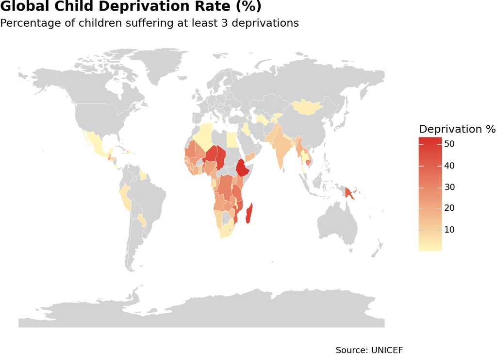

World map showing child deprivation rates — darker red indicates higher deprivation

```python
import pandas as pd
import geopandas as gpd
from plotnine import *
import warnings
warnings.filterwarnings("ignore")

indicator2 = pd.read_csv("unicef_indicator_2.csv")
metadata = pd.read_csv("unicef_metadata.csv")
indicator2.columns = indicator2.columns.str.strip()
indicator2 = indicator2.rename(columns={"obs_value(total)": "deprivation_rate", "obs_value(female)": "deprivation_female", "obs_value(male)": "deprivation_male"})
metadata = metadata.rename(columns={"GDP per capita (constant 2015 US$)": "gdp_per_capita", "Life expectancy at birth, total (years)": "life_expectancy", "Population, total": "population"})

url = "https://naturalearth.s3.amazonaws.com/110m_cultural/ne_110m_admin_0_countries.zip"
world = gpd.read_file(url)
world_map = world.merge(indicator2[["alpha_3_code", "deprivation_rate"]], left_on="ADM0_A3", right_on="alpha_3_code", how="left")
world_map["deprivation_rate"] = world_map["deprivation_rate"].clip(0, 100)

(
    ggplot(world_map)
    + geom_map(aes(fill="deprivation_rate"), color="white", size=0.1)
    + scale_fill_gradient(low="#fff7bc", high="#d73027", na_value="lightgrey")
    + labs(title="Global Child Deprivation Rate (%)", subtitle="Percentage of children suffering at least 3 deprivations", fill="Deprivation %", caption="Source: UNICEF")
    + theme_void()
    + theme(plot_title=element_text(size=14, weight="bold"))
)
```

## Top 10 Countries with Highest Deprivation

**Ethiopia, Madagascar and Chad** top the list — all located in Sub-Saharan Africa. These countries face compounding challenges including poverty, conflict, and limited public services.

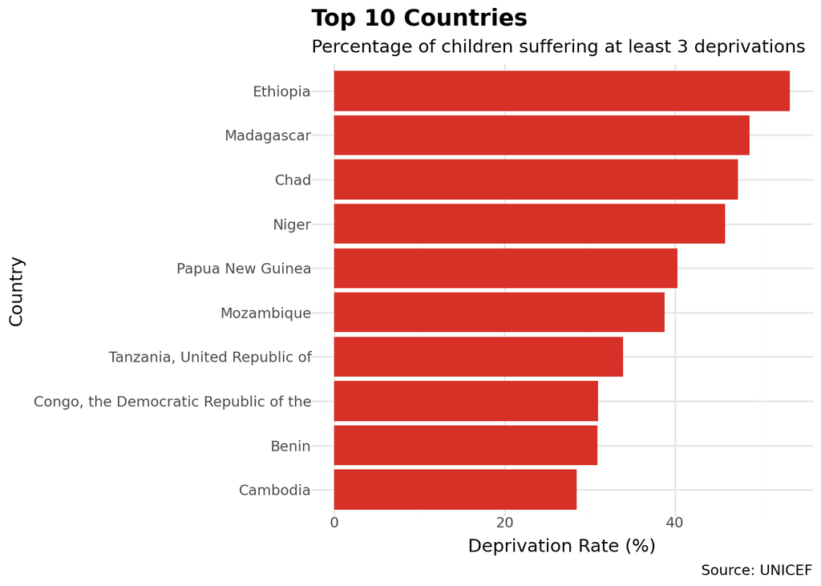

Top 10 countries ranked by child deprivation rate — all are in the developing world

```python
top10 = indicator2[["country", "deprivation_rate"]].dropna()
top10 = top10.sort_values("deprivation_rate", ascending=False).head(10)

(
    ggplot(top10, aes(x="reorder(country, deprivation_rate)", y="deprivation_rate"))
    + geom_bar(stat="identity", fill="#d73027")
    + coord_flip()
    + labs(title="Top 10 Countries", subtitle="Percentage of children suffering at least 3 deprivations", x="Country", y="Deprivation Rate (%)", caption="Source: UNICEF")
    + theme_minimal()
    + theme(plot_title=element_text(size=14, weight="bold"))
)
```

## GDP per Capita vs Child Deprivation

There is a **clear negative relationship** between a country’s wealth and its child deprivation rate. Wealthier nations like **Costa Rica** maintain very low deprivation, while poorer nations like **Ethiopia** and **Niger** struggle with rates above 40%.

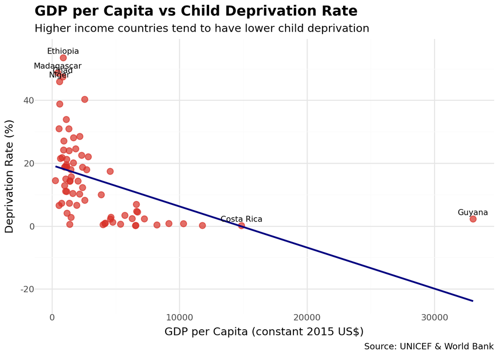

Scatterplot showing the relationship between GDP per capita and child deprivation — wealthier countries have lower deprivation

```python
metadata_latest = metadata.sort_values("year").groupby("country").last().reset_index()
scatter_data = indicator2[["country", "deprivation_rate"]].merge(metadata_latest[["country", "gdp_per_capita"]], on="country", how="inner").dropna()
highlight = ["Ethiopia", "Madagascar", "Chad", "Costa Rica", "Guyana", "Niger"]
to_label = scatter_data[scatter_data["country"].isin(highlight)]

(
    ggplot(scatter_data, aes(x="gdp_per_capita", y="deprivation_rate"))
    + geom_point(color="#d73027", size=3, alpha=0.7)
    + geom_smooth(method="lm", color="navy", se=False)
    + geom_text(data=to_label, mapping=aes(label="country"), size=8, nudge_y=2)
    + labs(title="GDP per Capita vs Child Deprivation Rate", subtitle="Higher income countries tend to have lower child deprivation", x="GDP per Capita (constant 2015 US$)", y="Deprivation Rate (%)", caption="Source: UNICEF & World Bank")
    + theme_minimal()
    + theme(plot_title=element_text(size=14, weight="bold"))
)
```

## Life Expectancy Over Time

Countries with high child deprivation consistently show **lower life expectancy**. Cambodia’s dramatic dip in the late 1970s reflects the impact of the **Khmer Rouge genocide**. Encouragingly, all countries show an **upward trend** in recent decades.

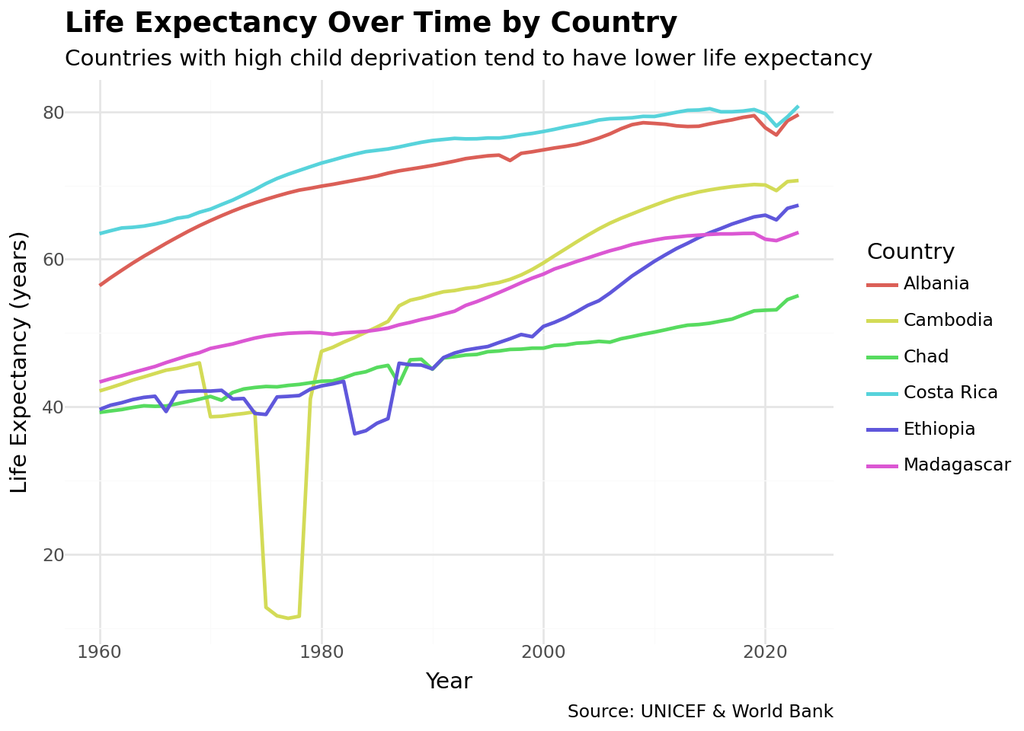

Life expectancy trends from 1960 to present — high deprivation countries consistently lag behind

```python
countries = ["Ethiopia", "Madagascar", "Chad", "Costa Rica", "Albania", "Cambodia"]
timeseries_data = metadata[metadata["country"].isin(countries)][["country", "year", "life_expectancy"]].dropna()

(
    ggplot(timeseries_data, aes(x="year", y="life_expectancy", color="country"))
    + geom_line(size=1)
    + labs(title="Life Expectancy Over Time by Country", subtitle="Countries with high child deprivation tend to have lower life expectancy", x="Year", y="Life Expectancy (years)", color="Country", caption="Source: UNICEF & World Bank")
    + theme_minimal()
    + theme(plot_title=element_text(size=14, weight="bold"))
)
```

## Conclusion

> *Urgent investment in education, healthcare, and economic development in the most affected regions is critical to reversing these trends.*